# Statement

The Sure Tomorrow insurance company wants to solve several tasks with the help of Machine Learning and you are asked to evaluate that possibility.

- Task 1: Find customers who are similar to a given customer. This will help the company's agents with marketing.
- Task 2: Predict whether a new customer is likely to receive an insurance benefit. Can a prediction model do better than a dummy model?
- Task 3: Predict the number of insurance benefits a new customer is likely to receive using a linear regression model.
- Task 4: Protect clients' personal data without breaking the model from the previous task. It's necessary to develop a data transformation algorithm that would make it hard to recover personal information if the data fell into the wrong hands. This is called data masking, or data obfuscation. But the data should be protected in such a way that the quality of machine learning models doesn't suffer. You don't need to pick the best model, just prove that the algorithm works correctly.

# Data Preprocessing & Exploration

## Initialization

```python
import numpy as np
import pandas as pd
import seaborn as sns

import sklearn.linear_model
from sklearn.linear_model import LinearRegression
import sklearn.metrics
from sklearn.metrics import mean_squared_error, r2_score
import sklearn.neighbors
from sklearn.neighbors import NearestNeighbors
from sklearn.neighbors import KNeighborsClassifier
import sklearn.preprocessing

import math

from sklearn.model_selection import train_test_split

from scipy.spatial import distance

from IPython.display import display
```

## Load Data

```python
df = pd.read_csv('/datasets/insurance_us.csv')
```

```python
# Make column names consistent

df = df.rename(columns={'Gender': 'gender', 'Age': 'age', 'Salary': 'income', 'Family members': 'family_members', 'Insurance benefits': 'insurance_benefits'})
```

```python
# Inspect a sample of the data
df.sample(10)
```

|  | gender | age | income | family_members | insurance_benefits |
| --- | --- | --- | --- | --- | --- |
| 1093 | 1 | 41.0 | 30200.0 | 0 | 0 |
| 2792 | 0 | 40.0 | 21100.0 | 0 | 0 |
| 2455 | 1 | 22.0 | 25600.0 | 0 | 0 |
| 439 | 1 | 27.0 | 41300.0 | 1 | 0 |
| 101 | 0 | 49.0 | 42500.0 | 1 | 2 |
| 1710 | 0 | 22.0 | 50900.0 | 1 | 0 |
| 1240 | 1 | 32.0 | 24200.0 | 1 | 0 |
| 1982 | 0 | 27.0 | 48700.0 | 0 | 0 |
| 1505 | 0 | 23.0 | 30600.0 | 1 | 0 |
| 3251 | 0 | 49.0 | 25900.0 | 1 | 2 |

```python
# Look at the properties of the data
df.info()
```

```
<class 'pandas.core.frame.DataFrame'>
RangeIndex: 5000 entries, 0 to 4999
Data columns (total 5 columns):
 #   Column              Non-Null Count  Dtype
---  ------              --------------  -----
 0   gender              5000 non-null   int64
 1   age                 5000 non-null   float64
 2   income              5000 non-null   float64
 3   family_members      5000 non-null   int64
 4   insurance_benefits  5000 non-null   int64
dtypes: float64(2), int64(3)
memory usage: 195.4 KB
```

```python
# Make age type an int rather than a float
df['age'] = df['age'].astype('int')
```

```python
# check to see that the conversion was successful
df.info()
```

```
<class 'pandas.core.frame.DataFrame'>
RangeIndex: 5000 entries, 0 to 4999
Data columns (total 5 columns):
 #   Column              Non-Null Count  Dtype
---  ------              --------------  -----
 0   gender              5000 non-null   int64
 1   age                 5000 non-null   int64
 2   income              5000 non-null   float64
 3   family_members      5000 non-null   int64
 4   insurance_benefits  5000 non-null   int64
dtypes: float64(1), int64(4)
memory usage: 195.4 KB
```

```python
# Look at the data's descriptive statistics.

df.describe()
```

|  | gender | age | income | family_members | insurance_benefits |
| --- | --- | --- | --- | --- | --- |
| count | 5000.000000 | 5000.000000 | 5000.000000 | 5000.000000 | 5000.000000 |
| mean | 0.499000 | 30.952800 | 39916.360000 | 1.194200 | 0.148000 |
| std | 0.500049 | 8.440807 | 9900.083569 | 1.091387 | 0.463183 |
| min | 0.000000 | 18.000000 | 5300.000000 | 0.000000 | 0.000000 |
| 25% | 0.000000 | 24.000000 | 33300.000000 | 0.000000 | 0.000000 |
| 50% | 0.000000 | 30.000000 | 40200.000000 | 1.000000 | 0.000000 |
| 75% | 1.000000 | 37.000000 | 46600.000000 | 2.000000 | 0.000000 |
| max | 1.000000 | 65.000000 | 79000.000000 | 6.000000 | 5.000000 |

```
array([[<AxesSubplot:title={'center':'gender'}>,
        <AxesSubplot:title={'center':'age'}>],
       [<AxesSubplot:title={'center':'income'}>,
        <AxesSubplot:title={'center':'family_members'}>],
       [<AxesSubplot:title={'center':'insurance_benefits'}>,
        <AxesSubplot:>]], dtype=object)
```

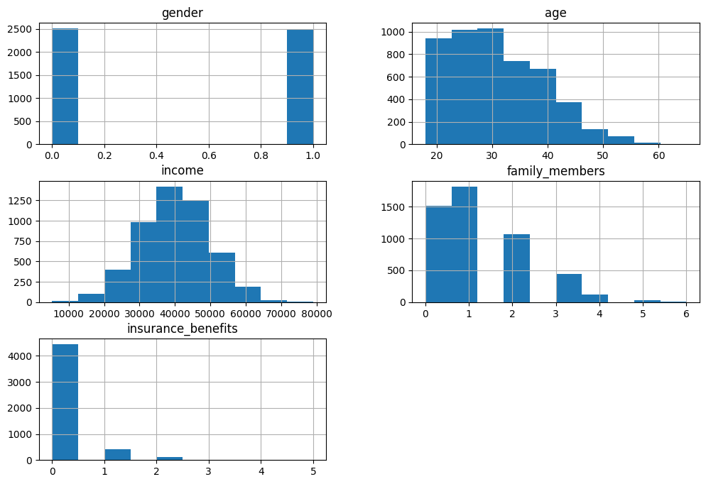

```python
# Further inspect the data
df.hist(figsize = [12,8])
```

## EDA

Let's quickly check whether there are certain groups of customers by looking at the pair plot.

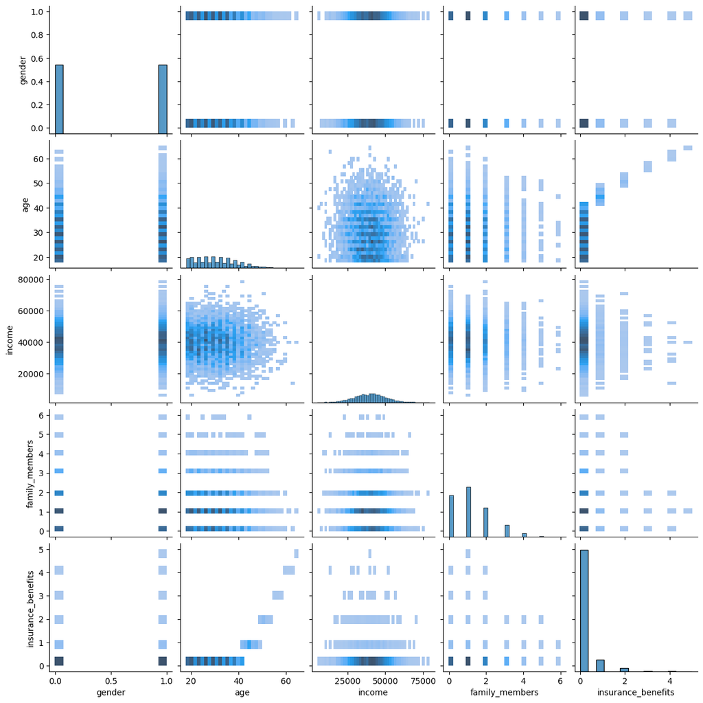

```python
g = sns.pairplot(df, kind='hist')
g.fig.set_size_inches(12, 12)
```

# Task 1. Similar Customers

In the language of ML, it is necessary to develop a procedure that returns k nearest neighbors (objects) for a given object based on the distance between the objects.

You may want to review the following lessons (chapter -> lesson)

- Distance Between Vectors -> Euclidean Distance
- Distance Between Vectors -> Manhattan Distance

To solve the task, we can try different distance metrics.

Write a function that returns k nearest neighbors for an $n^{th}$ object based on a specified distance metric. The number of received insurance benefits should not be taken into account for this task.

You can use a ready implementation of the kNN algorithm from scikit-learn (check [the link](https://scikit-learn.org/stable/modules/generated/sklearn.neighbors.NearestNeighbors.html#sklearn.neighbors.NearestNeighbors)) or use your own.

Test it for four combination of two cases

- Scaling
  - the data is not scaled
  - the data is scaled with the [MaxAbsScaler](https://scikit-learn.org/stable/modules/generated/sklearn.preprocessing.MaxAbsScaler.html) scaler
- Distance Metrics
  - Euclidean
  - Manhattan

Answer these questions:

- Does the data being not scaled affect the kNN algorithm? If so, how does that appear?
- How similar are the results using the Manhattan distance metric (regardless of the scaling)?

```python
feature_names = ['gender', 'age', 'income', 'family_members']
```

```python
def get_knn(df, n, k, metric):

    """
    Returns k nearest neighbors

    :param df: pandas DataFrame used to find similar objects within
    :param n: object no for which the nearest neighbours are looked for
    :param k: the number of the nearest neighbours to return
    :param metric: name of distance metric
    """

    # Create and fit NearestNeighbors model
    nbrs = NearestNeighbors(n_neighbors = k, metric = metric)  # Model to find k neighbors using specified distance
    nbrs.fit(df[feature_names])                                # Trains the model on all features

    # Find k nearest neighbors to insurance holder n
    nbrs_distances, nbrs_indices = nbrs.kneighbors(
        [df.iloc[n][feature_names]],     # The insured holders being compared by features
        k,                               # No. of neighbors to find
        return_distance=True)            # Return both distances and indices

    # Create a result DF
    df_res = pd.concat([
        df.iloc[nbrs_indices[0]],                                                     # Get the neighbor rows
        pd.DataFrame(nbrs_distances.T, index=nbrs_indices[0], columns=['distance'])   # Adds distance column
        ], axis=1)                                                                    # pd.concat([...], axis = 1): Combines two DF side by side

    return df_res
```

```python
# Test the function works - find the 3 most similar insurers to insurer no.5(index 5)
# returned w/ euclidean distance performed
get_knn(df, n=5, k=3, metric = 'euclidean')
```

|  | gender | age | income | family_members | insurance_benefits | distance |
| --- | --- | --- | --- | --- | --- | --- |
| 5 | 1 | 43 | 41000.0 | 2 | 1 | 0.000000 |
| 1995 | 0 | 45 | 41000.0 | 0 | 1 | 3.000000 |
| 3972 | 1 | 40 | 41000.0 | 1 | 0 | 3.162278 |

```python
# # returned w/ Manhattan distance performed
get_knn(df, n=5, k=3, metric = 'cityblock')
```

|  | gender | age | income | family_members | insurance_benefits | distance |
| --- | --- | --- | --- | --- | --- | --- |
| 5 | 1 | 43 | 41000.0 | 2 | 1 | 0.0 |
| 3801 | 0 | 46 | 41000.0 | 2 | 1 | 4.0 |
| 3972 | 1 | 40 | 41000.0 | 1 | 0 | 4.0 |

**SCALING THE DATA:**

```python
# Feature columns
feature_names = ['gender', 'age', 'income', 'family_members']

# Create MaxAbsScaler object - scales each feature to range between [(-)1 - 1] by dividing by the max absolute value
# .fit() - learns the maximum absolute value for each feature
transformer_mas = sklearn.preprocessing.MaxAbsScaler().fit(df[feature_names].to_numpy())

# Copy DF to maintain original
df_scaled = df.copy()

# Take the feature columns and replace the original values with the scaled values in copied DF
# .transform() scales each value by dividing by the maximum absolute value
df_scaled.loc[:, feature_names] = transformer_mas.transform(df[feature_names].to_numpy())
```

```python
df_scaled.sample(5)
```

|  | gender | age | income | family_members | insurance_benefits |
| --- | --- | --- | --- | --- | --- |
| 108 | 1.0 | 0.600000 | 0.507595 | 0.333333 | 0 |
| 4735 | 1.0 | 0.707692 | 0.236709 | 0.000000 | 1 |
| 2966 | 0.0 | 0.415385 | 0.865823 | 0.000000 | 0 |
| 277 | 1.0 | 0.492308 | 0.546835 | 0.000000 | 0 |
| 549 | 0.0 | 0.523077 | 0.525316 | 0.333333 | 0 |

**CHECK THE DIFFERENCES FROM NON-SCALED(NS) TO SCALED(S):**

```python
# Pick one person to analyze
test_person = 5

# Try different combinations
for k in [3, 5, 10]:
    print(f"\n=== k={k} ===")
    print("Scaled Euclidean:")
    display(get_knn(df_scaled, n=test_person, k=k, metric='euclidean'))

    print("\nNot Scaled Euclidean:")
    display(get_knn(df, n=test_person, k=k, metric='euclidean'))

    print(f"\n=== k={k} ===")
    print("Scaled Manhattan:")
    display(get_knn(df_scaled, n=test_person, k=k, metric='cityblock'))

    print("\nNot Scaled Manhattan:")
    display(get_knn(df, n=test_person, k=k, metric='cityblock'))
```

```
=== k=3 ===
Scaled Euclidean:
```

|  | gender | age | income | family_members | insurance_benefits | distance |
| --- | --- | --- | --- | --- | --- | --- |
| 5 | 1.0 | 0.661538 | 0.518987 | 0.333333 | 1 | 0.000000 |
| 1147 | 1.0 | 0.646154 | 0.516456 | 0.333333 | 0 | 0.015592 |
| 4074 | 1.0 | 0.661538 | 0.501266 | 0.333333 | 1 | 0.017722 |

```
Not Scaled Euclidean:
```

|  | gender | age | income | family_members | insurance_benefits | distance |
| --- | --- | --- | --- | --- | --- | --- |
| 5 | 1 | 43 | 41000.0 | 2 | 1 | 0.000000 |
| 1995 | 0 | 45 | 41000.0 | 0 | 1 | 3.000000 |
| 3972 | 1 | 40 | 41000.0 | 1 | 0 | 3.162278 |

```
=== k=3 ===
Scaled Manhattan:
```

|  | gender | age | income | family_members | insurance_benefits | distance |
| --- | --- | --- | --- | --- | --- | --- |
| 5 | 1.0 | 0.661538 | 0.518987 | 0.333333 | 1 | 0.000000 |
| 4074 | 1.0 | 0.661538 | 0.501266 | 0.333333 | 1 | 0.017722 |
| 1147 | 1.0 | 0.646154 | 0.516456 | 0.333333 | 0 | 0.017916 |

```
Not Scaled Manhattan:
```

|  | gender | age | income | family_members | insurance_benefits | distance |
| --- | --- | --- | --- | --- | --- | --- |
| 5 | 1 | 43 | 41000.0 | 2 | 1 | 0.0 |
| 3801 | 0 | 46 | 41000.0 | 2 | 1 | 4.0 |
| 3972 | 1 | 40 | 41000.0 | 1 | 0 | 4.0 |

```
=== k=5 ===
Scaled Euclidean:
```

|  | gender | age | income | family_members | insurance_benefits | distance |
| --- | --- | --- | --- | --- | --- | --- |
| 5 | 1.0 | 0.661538 | 0.518987 | 0.333333 | 1 | 0.000000 |
| 1147 | 1.0 | 0.646154 | 0.516456 | 0.333333 | 0 | 0.015592 |
| 4074 | 1.0 | 0.661538 | 0.501266 | 0.333333 | 1 | 0.017722 |
| 1019 | 1.0 | 0.646154 | 0.501266 | 0.333333 | 0 | 0.023468 |
| 2962 | 1.0 | 0.630769 | 0.520253 | 0.333333 | 0 | 0.030795 |

```
Not Scaled Euclidean:
```

|  | gender | age | income | family_members | insurance_benefits | distance |
| --- | --- | --- | --- | --- | --- | --- |
| 5 | 1 | 43 | 41000.0 | 2 | 1 | 0.000000 |
| 1995 | 0 | 45 | 41000.0 | 0 | 1 | 3.000000 |
| 3972 | 1 | 40 | 41000.0 | 1 | 0 | 3.162278 |
| 3801 | 0 | 46 | 41000.0 | 2 | 1 | 3.162278 |
| 4763 | 1 | 46 | 41000.0 | 1 | 1 | 3.162278 |

```
=== k=5 ===
Scaled Manhattan:
```

|  | gender | age | income | family_members | insurance_benefits | distance |
| --- | --- | --- | --- | --- | --- | --- |
| 5 | 1.0 | 0.661538 | 0.518987 | 0.333333 | 1 | 0.000000 |
| 4074 | 1.0 | 0.661538 | 0.501266 | 0.333333 | 1 | 0.017722 |
| 1147 | 1.0 | 0.646154 | 0.516456 | 0.333333 | 0 | 0.017916 |
| 2962 | 1.0 | 0.630769 | 0.520253 | 0.333333 | 0 | 0.032035 |
| 1019 | 1.0 | 0.646154 | 0.501266 | 0.333333 | 0 | 0.033106 |

```
Not Scaled Manhattan:
```

|  | gender | age | income | family_members | insurance_benefits | distance |
| --- | --- | --- | --- | --- | --- | --- |
| 5 | 1 | 43 | 41000.0 | 2 | 1 | 0.0 |
| 3972 | 1 | 40 | 41000.0 | 1 | 0 | 4.0 |
| 4763 | 1 | 46 | 41000.0 | 1 | 1 | 4.0 |
| 3801 | 0 | 46 | 41000.0 | 2 | 1 | 4.0 |
| 1995 | 0 | 45 | 41000.0 | 0 | 1 | 5.0 |

```
=== k=10 ===
Scaled Euclidean:
```

|  | gender | age | income | family_members | insurance_benefits | distance |
| --- | --- | --- | --- | --- | --- | --- |
| 5 | 1.0 | 0.661538 | 0.518987 | 0.333333 | 1 | 0.000000 |
| 1147 | 1.0 | 0.646154 | 0.516456 | 0.333333 | 0 | 0.015592 |
| 4074 | 1.0 | 0.661538 | 0.501266 | 0.333333 | 1 | 0.017722 |
| 1019 | 1.0 | 0.646154 | 0.501266 | 0.333333 | 0 | 0.023468 |
| 2962 | 1.0 | 0.630769 | 0.520253 | 0.333333 | 0 | 0.030795 |
| 2128 | 1.0 | 0.692308 | 0.512658 | 0.333333 | 1 | 0.031413 |
| 106 | 1.0 | 0.692308 | 0.526582 | 0.333333 | 1 | 0.031693 |
| 2206 | 1.0 | 0.692308 | 0.530380 | 0.333333 | 1 | 0.032811 |
| 2352 | 1.0 | 0.692308 | 0.531646 | 0.333333 | 1 | 0.033271 |
| 719 | 1.0 | 0.630769 | 0.532911 | 0.333333 | 0 | 0.033773 |

```
Not Scaled Euclidean:
```

|  | gender | age | income | family_members | insurance_benefits | distance |
| --- | --- | --- | --- | --- | --- | --- |
| 5 | 1 | 43 | 41000.0 | 2 | 1 | 0.000000 |
| 1995 | 0 | 45 | 41000.0 | 0 | 1 | 3.000000 |
| 4763 | 1 | 46 | 41000.0 | 1 | 1 | 3.162278 |
| 3972 | 1 | 40 | 41000.0 | 1 | 0 | 3.162278 |
| 3801 | 0 | 46 | 41000.0 | 2 | 1 | 3.162278 |
| 2759 | 0 | 47 | 41000.0 | 3 | 1 | 4.242641 |
| 2717 | 0 | 37 | 41000.0 | 0 | 0 | 6.403124 |
| 3434 | 1 | 36 | 41000.0 | 2 | 0 | 7.000000 |
| 1740 | 0 | 36 | 41000.0 | 1 | 0 | 7.141428 |
| 2876 | 0 | 35 | 41000.0 | 2 | 0 | 8.062258 |

```
=== k=10 ===
Scaled Manhattan:
```

|  | gender | age | income | family_members | insurance_benefits | distance |
| --- | --- | --- | --- | --- | --- | --- |
| 5 | 1.0 | 0.661538 | 0.518987 | 0.333333 | 1 | 0.000000 |
| 4074 | 1.0 | 0.661538 | 0.501266 | 0.333333 | 1 | 0.017722 |
| 1147 | 1.0 | 0.646154 | 0.516456 | 0.333333 | 0 | 0.017916 |
| 2962 | 1.0 | 0.630769 | 0.520253 | 0.333333 | 0 | 0.032035 |
| 1019 | 1.0 | 0.646154 | 0.501266 | 0.333333 | 0 | 0.033106 |
| 2128 | 1.0 | 0.692308 | 0.512658 | 0.333333 | 1 | 0.037098 |
| 106 | 1.0 | 0.692308 | 0.526582 | 0.333333 | 1 | 0.038364 |
| 2206 | 1.0 | 0.692308 | 0.530380 | 0.333333 | 1 | 0.042162 |
| 2352 | 1.0 | 0.692308 | 0.531646 | 0.333333 | 1 | 0.043427 |
| 719 | 1.0 | 0.630769 | 0.532911 | 0.333333 | 0 | 0.044693 |

```
Not Scaled Manhattan:
```

|  | gender | age | income | family_members | insurance_benefits | distance |
| --- | --- | --- | --- | --- | --- | --- |
| 5 | 1 | 43 | 41000.0 | 2 | 1 | 0.0 |
| 3972 | 1 | 40 | 41000.0 | 1 | 0 | 4.0 |
| 4763 | 1 | 46 | 41000.0 | 1 | 1 | 4.0 |
| 3801 | 0 | 46 | 41000.0 | 2 | 1 | 4.0 |
| 1995 | 0 | 45 | 41000.0 | 0 | 1 | 5.0 |
| 2759 | 0 | 47 | 41000.0 | 3 | 1 | 6.0 |
| 3434 | 1 | 36 | 41000.0 | 2 | 0 | 7.0 |
| 2717 | 0 | 37 | 41000.0 | 0 | 0 | 9.0 |
| 1740 | 0 | 36 | 41000.0 | 1 | 0 | 9.0 |
| 2876 | 0 | 35 | 41000.0 | 2 | 0 | 9.0 |

```python
# Look at the scaled versions picks for insurer no. 5 in its original form
display(df.loc[[5,4074, 1147,2962,1019,2128,106,2206,2352,719]])
```

|  | gender | age | income | family_members | insurance_benefits |
| --- | --- | --- | --- | --- | --- |
| 5 | 1 | 43 | 41000.0 | 2 | 1 |
| 4074 | 1 | 43 | 39600.0 | 2 | 1 |
| 1147 | 1 | 42 | 40800.0 | 2 | 0 |
| 2962 | 1 | 41 | 41100.0 | 2 | 0 |
| 1019 | 1 | 42 | 39600.0 | 2 | 0 |
| 2128 | 1 | 45 | 40500.0 | 2 | 1 |
| 106 | 1 | 45 | 41600.0 | 2 | 1 |
| 2206 | 1 | 45 | 41900.0 | 2 | 1 |
| 2352 | 1 | 45 | 42000.0 | 2 | 1 |
| 719 | 1 | 41 | 42100.0 | 2 | 0 |

**Order & Rank Remained the Same:** SE and SM

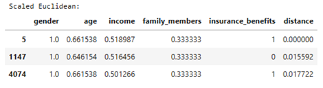

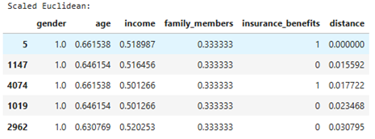

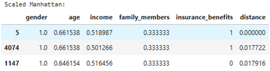

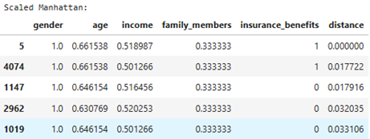

**Order and Rank Differ:** NSE and NSM

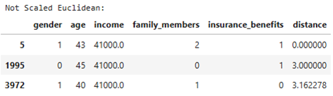

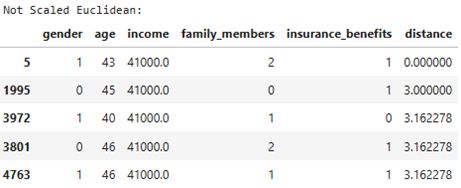

- Order differs from k=5 to k=10

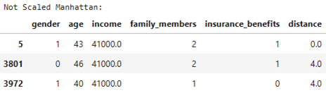

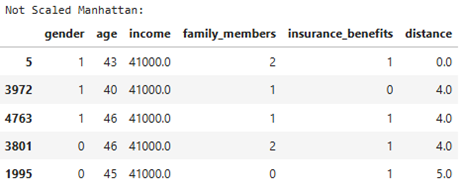

- Oder differs from k=3 to k=5

**Scaled Picks (Original Form)**

**Summary: Impact of Feature Scaling on Nearest Neighbor Selection**

When features aren't scaled, income dominates the distance calculation due to its much larger magnitude (thousands) compared to other features like age (0-100) or gender (0-1). This causes the algorithm to prioritize income similarity while largely ignoring other attributes.

**Key Finding:**

All 10 unscaled neighbors have identical incomes ($41,000) but show high variation in other features. In contrast, scaled neighbors show balanced similarity across all features.

**Unscaled Results (k=10, person at index 5)**

- Without scaling, income is the sole determining factor:
- **Gender:** High variation despite being a categorical feature
  - 6 people with gender=0, only 4 with gender=1 (original gender)
  - **Note:** Demonstrates gender is effectively ignored in distance calculation
- **Age:** Wide variation
  - Range: 35-47 years
  - Maximum difference: 8 years (4x larger than scaled)
- **Income:** Zero variation (all exactly (\$)41,000)
  - Income is the dominant feature, overriding all other similarities
- **Family Members:** Significant variation
  - Range: 0-3 members
  - Maximum difference: 2 members
- **Insurance Benefits:** Original [1]
  - Mix of 0 (5 people) and 1 (5 people)

**Conclusion:**

Scaling ensures all features contribute equally to similarity calculations, resulting in more genuinely similar neighbors rather than neighbors that only match on the highest-magnitude feature.

**Answers to the questions**

**Does the data being not scaled affect the kNN algorithm? If so, how does that appear?**

Yes, the unscaled data has identical incomes ($41,000) but show high variation in other features. In contrast, scaled data shows balanced similarity across all features.

**How similar are the results using the Manhattan distance metric (regardless of the scaling)?**

# Task 2. Is Customer Likely to Receive Insurance Benefit?

In terms of machine learning we can look at this like a binary classification task.

With `insurance_benefits` being more than zero as the target, evaluate whether the kNN classification approach can do better than a dummy model.

Instructions:

- Build a KNN-based classifier and measure its quality with the F1 metric for k=1..10 for both the original data and the scaled one. That'd be interesting to see how k may influece the evaluation metric, and whether scaling the data makes any difference. You can use a ready implemention of the kNN classification algorithm from scikit-learn (check [the link](https://scikit-learn.org/stable/modules/generated/sklearn.neighbors.KNeighborsClassifier.html)) or use your own.
- Build the dummy model which is just random for this case. It should return "1" with some probability. Let's test the model with four probability values: 0, the probability of paying any insurance benefit, 0.5, 1.

The probability of paying any insurance benefit can be defined as

$$ P\{\text{insurance benefit received}\}=\frac{\text{number of clients received any insurance benefit}}{\text{total number of clients}}. $$

Split the whole data in the 70:30 proportion for the training/testing parts.

```python
# calculate the target

df['insurance_benefits_received'] = (df['insurance_benefits'] > 0).astype('int')
```

```python
# check for the class imbalance with value_counts()

display(df['insurance_benefits'].value_counts())

display(df['insurance_benefits_received'].value_counts())
```

```
0    4436
1     423
2     115
3      18
4       7
5       1
Name: insurance_benefits, dtype: int64
```

```
0    4436
1     564
Name: insurance_benefits_received, dtype: int64
```

```python
# f1 and confusion matrix output

def eval_classifier(y_true, y_pred):

    # f1 score
    f1_score = sklearn.metrics.f1_score(y_true, y_pred)
    print(f'F1: {f1_score:.2f}')

    # confusion matrix
    cm = sklearn.metrics.confusion_matrix(y_true, y_pred, normalize='all')
    print('Confusion Matrix')
    print(cm)
```

```python
# generating output of a random model; sanity check for model performance

def rnd_model_predict(P, size, seed=42):

    rng = np.random.default_rng(seed=seed)    # creates a random number generator with a fixed seed
    return rng.binomial(n=1, p=P, size=size)  # performs a binomial distribution
```

```python
# Testing 4 random prediction probabilities


for P in [0, df['insurance_benefits_received'].sum() / len(df), 0.5, 1]:

    print(f'The probability: {P:.2f}')
    y_pred_rnd = rnd_model_predict(P, size=len(df), seed=42)

    eval_classifier(df['insurance_benefits_received'], y_pred_rnd)

    print()
```

```
The probability: 0.00
F1: 0.00
Confusion Matrix
[[0.8872 0.    ]
 [0.1128 0.    ]]

The probability: 0.11
F1: 0.12
Confusion Matrix
[[0.7914 0.0958]
 [0.0994 0.0134]]

The probability: 0.50
F1: 0.20
Confusion Matrix
[[0.456  0.4312]
 [0.053  0.0598]]

The probability: 1.00
F1: 0.20
Confusion Matrix
[[0.     0.8872]
 [0.     0.1128]]
```

```python
# Create target
target = df['insurance_benefits_received']

# Create features
features = df[feature_names]
features_scaled = df_scaled[feature_names]

# Split the data 70:30
# Not-scaled
features_train_ns, features_test_ns, target_train_ns, target_test_ns = train_test_split(features, target, test_size = 0.3, random_state = 42)
# Scaled
features_train_s, features_test_s, target_train_s, target_test_s = train_test_split(features_scaled, target, test_size = 0.3, random_state = 42)
```

```python
# Train the model for k = 1-10

print("=== KNN On Non-Scaled Data ===")
for k in range(1,11):
    model_ns = KNeighborsClassifier(n_neighbors = k)
    model_ns.fit(features_train_ns, target_train_ns)
    predictions_ns = model_ns.predict(features_test_ns)
    print("~~~~~~~~~~~~~~~~~~~~~~~~~~~~~~~~~~~~")
    print(f"k = {k}")
    print("-----")
    eval_classifier(target_test_ns, predictions_ns)
    print("~~~~~~~~~~~~~~~~~~~~~~~~~~~~~~~~~~~~")

print("\n=== KNN On Scaled Data ===")
for k in range(1,11):
    model_s = KNeighborsClassifier(n_neighbors=k)
    model_s.fit(features_train_s, target_train_s)
    predictions_s = model_s.predict(features_test_s)
    print("~~~~~~~~~~~~~~~~~~~~~~~~~~~~~~~~~~~~")
    print(f"k = {k}")
    print("-----")
    eval_classifier(target_test_s, predictions_s)
    print("~~~~~~~~~~~~~~~~~~~~~~~~~~~~~~~~~~~~")
```

```
=== KNN On Non-Scaled Data ===
~~~~~~~~~~~~~~~~~~~~~~~~~~~~~~~~~~~~
k = 1
-----
F1: 0.65
Confusion Matrix
[[0.87466667 0.018     ]
 [0.04666667 0.06066667]]
~~~~~~~~~~~~~~~~~~~~~~~~~~~~~~~~~~~~
~~~~~~~~~~~~~~~~~~~~~~~~~~~~~~~~~~~~
k = 2
-----
F1: 0.38
Confusion Matrix
[[0.89066667 0.002     ]
 [0.082      0.02533333]]
~~~~~~~~~~~~~~~~~~~~~~~~~~~~~~~~~~~~
~~~~~~~~~~~~~~~~~~~~~~~~~~~~~~~~~~~~
k = 3
-----
F1: 0.39
Confusion Matrix
[[0.88333333 0.00933333]
 [0.07933333 0.028     ]]
~~~~~~~~~~~~~~~~~~~~~~~~~~~~~~~~~~~~
~~~~~~~~~~~~~~~~~~~~~~~~~~~~~~~~~~~~
k = 4
-----
F1: 0.16
Confusion Matrix
[[0.88933333 0.00333333]
 [0.098      0.00933333]]
~~~~~~~~~~~~~~~~~~~~~~~~~~~~~~~~~~~~
~~~~~~~~~~~~~~~~~~~~~~~~~~~~~~~~~~~~
k = 5
-----
F1: 0.17
Confusion Matrix
[[0.88333333 0.00933333]
 [0.09666667 0.01066667]]
```

[output cut: 108 more lines]

```
k = 9
-----
F1: 0.93
Confusion Matrix
[[0.89133333 0.00133333]
 [0.01266667 0.09466667]]
~~~~~~~~~~~~~~~~~~~~~~~~~~~~~~~~~~~~
~~~~~~~~~~~~~~~~~~~~~~~~~~~~~~~~~~~~
k = 10
-----
F1: 0.91
Confusion Matrix
[[8.92000000e-01 6.66666667e-04]
 [1.66666667e-02 9.06666667e-02]]
~~~~~~~~~~~~~~~~~~~~~~~~~~~~~~~~~~~~
```

**Model Performance Comparison**

| Dummy Model Baseline |
| --- |

| Probability | F1 Score | True Negative | False Positive | False Negative | True Positive |
| --- | --- | --- | --- | --- | --- |
| 0.00 (Always predict 0) | 0.00 | 0.8872 | 0.0000 | 0.1128 | 0.0000 |
| 0.11 (Class distribution) | 0.12 | 0.7914 | 0.0958 | 0.0994 | 0.0134 |
| 0.50 (Random 50/50) | 0.20 | 0.4560 | 0.4312 | 0.0530 | 0.0598 |
| 1.00 (Always predict 1) | 0.20 | 0.0000 | 0.8872 | 0.0000 | 0.1128 |

| KNN Model Performance |
| --- |

| k | Non-Scaled F1 | Scaled F1 | F1 Improvement |
| --- | --- | --- | --- |
| 1 | 0.65 | **0.93** | +0.28 |
| 2 | 0.38 | **0.92** | +0.54 |
| 3 | 0.39 | **0.94** | +0.55 |
| 4 | 0.16 | **0.91** | +0.75 |
| 5 | 0.17 | **0.94** | +0.77 |
| 6 | 0.09 | **0.91** | +0.82 |
| 7 | 0.12 | **0.93** | +0.81 |
| 8 | 0.02 | **0.91** | +0.89 |
| 9 | 0.04 | **0.93** | +0.89 |
| 10 | 0.04 | **0.91** | +0.87 |

**Detailed Confusion Matrices**

| Non-Scaled Data (Selected k values) |
| --- |

| k | True Negative | False Positive | False Negative | True Positive |
| --- | --- | --- | --- | --- |
| 1 | 0.8747 | 0.0180 | 0.0467 | 0.0607 |
| 3 | 0.8833 | 0.0093 | 0.0793 | 0.0280 |
| 5 | 0.8833 | 0.0093 | 0.0967 | 0.0107 |
| 8 | 0.8927 | 0.0000 | 0.1060 | 0.0013 |
| 10 | 0.8927 | 0.0000 | 0.1053 | 0.0020 |

| Scaled Data (Selected k values) |
| --- |

| k | True Negative | False Positive | False Negative | True Positive |
| --- | --- | --- | --- | --- |
| 1 | 0.8880 | 0.0047 | 0.0093 | 0.0980 |
| 3 | 0.8893 | 0.0033 | 0.0093 | 0.0980 |
| 5 | 0.8893 | 0.0033 | 0.0100 | 0.0973 |
| 8 | 0.8920 | 0.0007 | 0.0167 | 0.0907 |
| 10 | 0.8920 | 0.0007 | 0.0167 | 0.0907 |

**Key Observations**

- **Best Dummy Model F1:** 0.20 (P=0.50 and P=1.00)
- **Best Non-Scaled KNN F1:** 0.65 (k=1)
- **Best Scaled KNN F1:** 0.94 (k=3 and k=5)
- **Scaled models consistently outperform non-scaled** across all k values
- **All scaled KNN models beat the dummy baseline** by a significant margin
- **Non-scaled** performance degrades rapidly as k increases, while **scaled** performance remains stable
- **Positive class:** 11.28%

**Confusion Matrix Analysis:**

- **Non-scaled** models degrade severely as k increases, with True Positives dropping from 0.0607 (k=1) to 0.0013 (k=8)
- At k=8, **non-scaled** models miss 10.6% of positive cases while correctly identifying only 0.13% - essentially failing to predict insurance benefit usage
- **Scaled** models maintain stable True Positive rates (0.090-0.098) and low False Positive rates (0.0007-0.0047) across all k values
- **Scaled** models successfully balance precision and recall, while **non-scaled** models sacrifice recall (missing actual positives) to avoid false alarms

**Conclusion**

A trained model performs substantially better than an untrained dummy model and a scaled trained model has proven to perform the most successfully.

# Task 3. Regression (with Linear Regression)

With `insurance_benefits` as the target, evaluate what RMSE would be for a Linear Regression model.

Build your own implementation of LR. For that, recall how the linear regression task's solution is formulated in terms of LA. Check RMSE for both the original data and the scaled one. Can you see any difference in RMSE between these two cases?

Denotation:

- $X$ — feature matrix, each row is a case, each column is a feature, the first column consists of unities
- $y$ — target (a vector)
- $\hat{y}$ — estimated tagret (a vector)
- $w$ — weight vector

The task of linear regression in the language of matrices can be formulated as

$$ y = Xw $$

The training objective then is to find such $w$ that it would minimize the L2-distance (MSE) between $Xw$ and $y$:

$$ \min_w d_2(Xw, y) \quad \text{or} \quad \min_w \text{MSE}(Xw, y) $$

It appears that there is analytical solution for the above:

$$ w = (X^T X)^{-1} X^T y $$

The formula above can be used to find the weights $w$ and the latter can be used to calculate predicted values

$$ \hat{y} = X_{val}w $$

Split the whole data in the 70:30 proportion for the training/validation parts. Use the RMSE metric for the model evaluation.

```python
# Create a Linear Regression class

class MyLinearRegression:

    def __init__(self):

        self.weights = None

    def fit(self, X, y):

        # adding the unities
        # add a column of 1s for the intercept
        X2 = np.append(np.ones([len(X), 1]), X, axis=1)
        # normal equation: compute weights
        self.weights = np.linalg.inv(X2.T @ X2) @ X2.T @ y

    def predict(self, X):

        # adding the unities
        # add a column of 1s for the intercept
        X2 = np.append(np.ones([len(X), 1]), X, axis=1)
        # normal equation: compute predicted values
        y_pred = X2 @ self.weights

        return y_pred
```

```python
# Evaluation Metrics: RMSE and R2
def eval_regressor(y_true, y_pred):

    rmse = math.sqrt(sklearn.metrics.mean_squared_error(y_true, y_pred))
    print(f'RMSE: {rmse:.2f}')

    r2_score = math.sqrt(sklearn.metrics.r2_score(y_true, y_pred))
    print(f'R2: {r2_score:.2f}')
```

```python
# Non-Scaled Data (feature/target)
X = df[['age', 'gender', 'income', 'family_members']].to_numpy()
y = df['insurance_benefits'].to_numpy()

# Split Non-Scaled Data
X_train, X_test, y_train, y_test = train_test_split(X, y, test_size=0.3, random_state=12345)



# Scaled Data (feature/target)
X_scaled = df_scaled[['age', 'gender', 'income', 'family_members']].to_numpy()

# Split Scaled Data
X_train_s, X_test_s, y_train_s, y_test_s = train_test_split(X_scaled, y, test_size=0.3, random_state=12345)


# Fit the Linear Model to the Non-Scaled Data
lr = MyLinearRegression()

lr.fit(X_train, y_train)
print("=== Non-Scaled Data ===\n")
print("Coefficient Parameters: w₀(Intercept) + w₁*age + w₂*gender + w₃*income + w₄*family_members")
print("------------------------------------------------------------------------------------------")
print(lr.weights)
print()

y_test_pred = lr.predict(X_test)
print("RMSE: prediction error  \nR2: model quality")
print("--------------------------------------------")
eval_regressor(y_test, y_test_pred)



# Fit the Linear Model to the Scaled Data
lr_scaled = MyLinearRegression()

lr_scaled.fit(X_train_s, y_train_s)
print()
print("\n=== Scaled Data ===\n")
print("Coefficient Parameters: w₀(Intercept) + w₁*age + w₂*gender + w₃*income + w₄*family_members")
print("------------------------------------------------------------------------------------------")
print(lr_scaled.weights)
print()

y_test_pred_s = lr_scaled.predict(X_test_s)
print("RMSE: prediction error  \nR2: model quality")
print("--------------------------------------------")
eval_regressor(y_test_s, y_test_pred_s)
```

```
=== Non-Scaled Data ===

Coefficient Parameters: w₀(Intercept) + w₁*age + w₂*gender + w₃*income + w₄*family_members
------------------------------------------------------------------------------------------
[-9.43539012e-01  3.57495491e-02  1.64272726e-02 -2.60743659e-07
 -1.16902127e-02]

RMSE: prediction error
R2: model quality
--------------------------------------------
RMSE: 0.34
R2: 0.66


=== Scaled Data ===

Coefficient Parameters: w₀(Intercept) + w₁*age + w₂*gender + w₃*income + w₄*family_members
------------------------------------------------------------------------------------------
[-0.94353901  2.32372069  0.01642727 -0.02059875 -0.07014128]

RMSE: prediction error
R2: model quality
--------------------------------------------
RMSE: 0.34
R2: 0.66
```

**Task 3: Regression with Linear Regression**

**Objective:** Predict the number of insurance benefits a customer is likely to receive using a custom-built linear regression model, and evaluate whether feature scaling affects model performance.

**Results**

[output not shown]

**Key Findings**

**RMSE Comparison:**

- Non-Scaled RMSE: 0.34
- Scaled RMSE: 0.34
- **Difference: None**

**Why Linear Regression is Scale-Invariant:**

Linear regression automatically compensates for feature scaling by adjusting the coefficient magnitudes. Notice how the coefficients differ dramatically between models:

- Age coefficient: 0.0357 (non-scaled) vs. 2.324 (scaled) - a 65x difference
- Income coefficient: -0.000000261 (non-scaled) vs. -0.0206 (scaled) - a 79,000x difference

Despite these vastly different coefficients, both models produce identical predictions because the scaling factors cancel out mathematically. When a feature is scaled down, its coefficient scales up proportionally, maintaining the same final prediction.

**Model Performance:**

**Conclusion**

Unlike distance-based algorithms (kNN), linear regression does not require feature scaling to achieve optimal performance. The analytical solution inherently accounts for different feature scales through coefficient adjustment. However, scaling may still be preferred in practice for:

- Improved numerical stability during matrix inversion
- Easier interpretation of relative feature importance
- Consistency with other models in a pipeline

# Task 4. Obfuscating Data

It best to obfuscate data by multiplying the numerical features (remember, they can be seen as the matrix $X$) by an invertible matrix $P$.

$$ X' = X \times P $$

Try to do that and check how the features' values will look like after the transformation. By the way, the invertible property is important here so make sure that $P$ is indeed invertible.

You may want to review the 'Matrices and Matrix Operations -> Matrix Multiplication' lesson to recall the rule of matrix multiplication and its implementation with NumPy.

```python
# Separate feature columns
personal_info_column_list = ['gender', 'age', 'income', 'family_members']
df_pn = df[personal_info_column_list]
```

```python
# Convert DF in a matrix
X = df_pn.to_numpy()
display(X)
```

```
array([[1.00e+00, 4.10e+01, 4.96e+04, 1.00e+00],
       [0.00e+00, 4.60e+01, 3.80e+04, 1.00e+00],
       [0.00e+00, 2.90e+01, 2.10e+04, 0.00e+00],
       ...,
       [0.00e+00, 2.00e+01, 3.39e+04, 2.00e+00],
       [1.00e+00, 2.20e+01, 3.27e+04, 3.00e+00],
       [1.00e+00, 2.80e+01, 4.06e+04, 1.00e+00]])
```

Generating a random matrix $P$.

```python
rng = np.random.default_rng(seed=42)
P = rng.random(size=(X.shape[1], X.shape[1]))
display(P)
```

```
array([[0.77395605, 0.43887844, 0.85859792, 0.69736803],
       [0.09417735, 0.97562235, 0.7611397 , 0.78606431],
       [0.12811363, 0.45038594, 0.37079802, 0.92676499],
       [0.64386512, 0.82276161, 0.4434142 , 0.22723872]])
```

Checking the matrix $P$ is invertible

```python
# Compute numeric inverse of P (raises error if P is singular)
P_inv = np.linalg.inv(P)
print(f"P Invertible: \n{P_inv}")
print()

# Multiply P by the inverse to check if we get the ID matrix
# Should get 1's on the diagonal
I_approx = P @ P_inv
print(f"Identity Check: \n{I_approx}")
print()

# Boolean Check to check I_approx is close to the ID Matrix
print(f"Identity Check: [T/F]: {np.allclose(I_approx, np.eye(P.shape[0]))}")
print()

# Condidtion number: measures numerical stability of inversion
cond = np.linalg.cond(P)
# Extremely Large = unstable
print("Condition Number:", cond)
print()

# Obfuscate data by multiplying X by P (scrambles features)
# Xp - same shape as X
Xp = X @ P
print(f"Obfuscated Feature Matrix: \n{Xp}")
print()
```

```
P Invertible:
[[ 0.41467992 -1.43783972  0.62798546  1.14001268]
 [-1.06101789  0.44219337  0.1329549   1.18425933]
 [ 1.42362442  1.60461607 -2.0553823  -1.53699695]
 [-0.11128575 -0.65813802  1.74995517 -0.11816316]]

Identity Check:
[[ 1.00000000e+00  1.85130588e-16 -2.97856902e-16 -3.91584367e-17]
 [ 6.23834470e-17  1.00000000e+00 -7.10568689e-17  8.24459807e-17]
 [ 1.03941594e-17  2.27454503e-17  1.00000000e+00 -5.77784356e-17]
 [-1.02697151e-16 -1.69379178e-16 -2.49945035e-17  1.00000000e+00]]

Identity Check: [T/F]: True

Condition Number: 9.680108367440537

Obfuscated Feature Matrix:
[[ 6359.71527314 22380.40467609 18424.09074184 46000.69669016]
 [ 4873.29406479 17160.36702982 14125.78076133 35253.45577301]
 [ 2693.11742928  9486.397744    7808.83156024 19484.86063067]
 ...
 [ 4346.2234249  15289.24126492 12586.16264392 31433.50888552]
 [ 4194.09324155 14751.9910242  12144.02930637 30323.88763426]
 [ 5205.46827354 18314.24814446 15077.01370762 37649.59295455]]
```

Can you guess the customers' ages or income after the transformation? **No** - shows the obfuscation worked

```python
display(Xp)
```

```
array([[ 6359.71527314, 22380.40467609, 18424.09074184, 46000.69669016],
       [ 4873.29406479, 17160.36702982, 14125.78076133, 35253.45577301],
       [ 2693.11742928,  9486.397744  ,  7808.83156024, 19484.86063067],
       ...,
       [ 4346.2234249 , 15289.24126492, 12586.16264392, 31433.50888552],
       [ 4194.09324155, 14751.9910242 , 12144.02930637, 30323.88763426],
       [ 5205.46827354, 18314.24814446, 15077.01370762, 37649.59295455]])
```

Can you recover the original data from $X'$ if you know $P$? Try to check that with calculations by moving $P$ from the right side of the formula above to the left one. The rules of matrix multiplcation are really helpful here. **Yes** - Xp @ P_inv recovers the original data

```python
# Recover original X by multiplying obfuscated data by the inverse
# Should equal the original X (within reason)
X_recovered = Xp @ P_inv
print(f"X_recovered: \n{X_recovered}")
print()
print(f"Original X: \n{X}")

# Boolean check wheather X_recovered is close to X
print()
print(f"X Recovered Check [T/F]: \n {np.allclose(X_recovered, X)}")
```

```
X_recovered:
[[ 1.00000000e+00  4.10000000e+01  4.96000000e+04  1.00000000e+00]
 [ 1.67952800e-12  4.60000000e+01  3.80000000e+04  1.00000000e+00]
 [-6.23021448e-13  2.90000000e+01  2.10000000e+04 -2.03032656e-13]
 ...
 [ 1.57996161e-12  2.00000000e+01  3.39000000e+04  2.00000000e+00]
 [ 1.00000000e+00  2.20000000e+01  3.27000000e+04  3.00000000e+00]
 [ 1.00000000e+00  2.80000000e+01  4.06000000e+04  1.00000000e+00]]

Original X:
[[1.00e+00 4.10e+01 4.96e+04 1.00e+00]
 [0.00e+00 4.60e+01 3.80e+04 1.00e+00]
 [0.00e+00 2.90e+01 2.10e+04 0.00e+00]
 ...
 [0.00e+00 2.00e+01 3.39e+04 2.00e+00]
 [1.00e+00 2.20e+01 3.27e+04 3.00e+00]
 [1.00e+00 2.80e+01 4.06e+04 1.00e+00]]

X Recovered Check [T/F]:
 True
```

Print all three cases for a few customers

- The original data
- The transformed one
- The reversed (recovered) one

```python
# Pull a sample of customers from X (original data)
X_sample = X[[251,252,253,254,255],:]

# Obfuscate the sample data
Xp_sample = X_sample @ P

# Recover the sample data
X_recovered_samp = Xp_sample @ P_inv

print(f"Original Data: \n{X_sample}")
print("--------------------------------------------------------------------")
print(f"Obfuscated Data: \n{Xp_sample}")
print("--------------------------------------------------------------------")
print(f"Recovered Data: \n{X_recovered_samp}")
print("--------------------------------------------------------------------")
```

```
Original Data:
[[1.00e+00 2.30e+01 4.57e+04 1.00e+00]
 [1.00e+00 3.30e+01 2.65e+04 1.00e+00]
 [1.00e+00 1.90e+01 4.70e+04 1.00e+00]
 [0.00e+00 3.20e+01 2.99e+04 1.00e+00]
 [0.00e+00 2.30e+01 4.28e+04 0.00e+00]]
--------------------------------------------------------------------
Obfuscated Data:
[[ 5858.37691344 20606.33831597 16964.27793269 42372.16407615]
 [ 3399.53693955 11968.68453189  9852.56726445 24586.13693331]
 [ 6024.54792653 21187.93754583 17443.27080539 43573.81430444]
 [ 3834.25515725 13498.58221994 11111.66080922 27735.65446306]
 [ 5485.42955751 19298.95745602 15887.6616503  39683.62100174]]
--------------------------------------------------------------------
Recovered Data:
[[ 1.00000000e+00  2.30000000e+01  4.57000000e+04  1.00000000e+00]
 [ 1.00000000e+00  3.30000000e+01  2.65000000e+04  1.00000000e+00]
 [ 1.00000000e+00  1.90000000e+01  4.70000000e+04  1.00000000e+00]
 [-1.23842216e-12  3.20000000e+01  2.99000000e+04  1.00000000e+00]
 [ 2.08124815e-12  2.30000000e+01  4.28000000e+04 -3.38202551e-12]]
--------------------------------------------------------------------
```

You can probably see that some values are not exactly the same as they are in the original data. What might be the reason for that? The differences are **negligible**. Computers store numbers in binary, which cannot always represent them exactly, so small rounding errors accumulate in floating-point math. These tiny errors add up, leading to the small discrepancies you see.

## Proof That Data Obfuscation Can Work with LR

The regression task has been solved with linear regression in this project. Your next task is to prove *analytically* that the given obfuscation method won't affect linear regression in terms of predicted values i.e. their values will remain the same. Can you believe that? Well, you don't have to, you should prove it!

So, the data is obfuscated and there is $X \times P$ instead of just $X$ now. Consequently, there are other weights $w_P$ as $$ w = (X^T X)^{-1} X^T y \quad \Rightarrow \quad w_P = [(XP)^T XP]^{-1} (XP)^T y $$

How would $w$ and $w_P$ be linked if you simplify the formula for $w_P$ above?

What would be predicted values with $w_P$?

What does that mean for the quality of linear regression if you measure it with RMSE?

Check Appendix B Properties of Matrices in the end of the notebook. There are useful formulas in there!

No code is necessary in this section, only analytical explanation!

**ANSWERS**

**Q1** How would $w$ and $w_P$ be linked if you simplify the formula for $w_P$ above?

**Answer:** The obfuscated weights are just the original weights multiplied by $P{-1}$. The weights $wp$ for the obfuscated data $X^{'} = XP$ are linked to the original weights $w$ by the formula:

$$ w_P = P^{-1} w $$

**Q2** What would be predicted values with $w_P$?

**Answer:** The predicted values using the obfuscated data are exactly the same as the original predicted values. $$ \hat{y} = Xw $$

**Q3** What does that mean for the quality of linear regression if you measure it with RMSE?

**Answer:** Obfuscating the features does not reduce the quality of the linear regression model. RMSE and other metrics remain the same.

Since the predicted values $\hat{y}_P$ are identical to the original predictions $\hat{y}$:

- The errors $y - \hat{y}_P$ are exactly the same as $y - \hat{y}$
- Therefore, any metric that depends on the errors (like RMSE, MAE, R²) does not change.

**Analytical proof**

**Q1**

Simplify $wp$

**Step 1.** Expand wp with the Reversivity of the Transpose of a Product of Matrices Formula:

| $(AB)^T = B^TA^T$ |
| --- |

Expanded: $$ w_P = (P^T X^T X P)^{-1} P^T X^T y $$

**Step 2.** Apply the Multiplicative Identity Property Formula:

| $IA = AI = A$ |
| --- |
| $A^{-1}A = AA^{-1} = I$ |
| $(AB)^{-1} = B^{-1}A^{-1}$ |

Expanded:

| $A = P^T$ |
| --- |
| $B = X^T X$ |
| $C = P$ |

$$ (P^T X^T X P)^-1 = P^{-1} (X^TX)^{-1} (P^T)^{-1} $$ Expanded Version: $$ w_P = P^{-1} (X^TX)^{-1} (P^T)^{-1} P^T X^T y $$

**Step 3.** Simplify with the Multiplicative Identity Property Formula

| $IA = AI = A$ |
| --- |
| $A^{-1}A = AA^{-1} = I$ |

Simplified: $$ (P^T)^{-1} P^T = I $$ Therefore: $$ w_P = P^{-1} (X^TX)^{-1} X^T y $$

**Step 4.** Check the formula for w and compare to wp $$ w = (X^T X)^{-1} X^T y $$ $$ w_P = P^{-1} (X^TX)^{-1} X^T y $$

**Step 5.** Simplify the formula by replacing part of the fromula with w $$ w_P = P^{-1} w $$

**Q2**

| $y = Xw$ |
| --- |
| $\hat{y} = X_{val}w$ |

**Step 1.** Replace $X_{val}$ with $XP$ $$ \hat{y} = (XP)w_P $$

**Step 2.** Substitute $w_P = P^{-1}w$ $$ \hat{y} = XP(P^{-1}w) $$

**Step 3.** Use the Multiplicative Identity Property Formula: $A^{-1}A = AA^{-1} = I$ $$ PP^{-1} = I $$ Therefore: $$ \hat{y} = Xw $$

## Test Linear Regression With Data Obfuscation

Now, let's prove Linear Regression can work computationally with the chosen obfuscation transformation.

Build a procedure or a class that runs Linear Regression optionally with the obfuscation. You can use either a ready implementation of Linear Regression from sciki-learn or your own.

Run Linear Regression for the original data and the obfuscated one, compare the predicted values and the RMSE, $R^2$ metric values. Is there any difference?

**Procedure**

- Create a square matrix $P$ of random numbers.
- Check that it is invertible. If not, repeat the first point until we get an invertible matrix.
- Comparing Linear Regression with original features X and obfuscated features Xp against target y
- Use $XP$ as the new feature matrix

```python
# Original Model
model_og = LinearRegression()
model_og.fit(X,y)
predictions_og = model_og.predict(X)
```

```python
# Obfuscated Model
model_obf = LinearRegression()
model_obf.fit(Xp,y)
predictions_obf = model_obf.predict(Xp)
```

```python
# Compare Metrics
mse_og = mean_squared_error(y, predictions_og)
mse_obf = mean_squared_error(y, predictions_og)
r2_og = r2_score(y, predictions_og)
r2_obf = r2_score(y, predictions_obf)

print("=== Metric Comparison ===\n")
print(f"RMSE (Original): {mse_og ** 0.5:.4f}  \nRMSE (Obfuscated): {mse_obf ** 0.5:.4f}")
print(f"\nR2 (Original): {r2_og:.4f} \nR2 (Obfuscated): {r2_obf:.4f}")
```

```
=== Metric Comparison ===

RMSE (Original): 0.3512
RMSE (Obfuscated): 0.3512

R2 (Original): 0.4249
R2 (Obfuscated): 0.4249
```

# Final Conclusion

🧩 **Feature Scaling, Model Performance, and Data Obfuscation**

**Overview**

Across all experiments — feature scaling, kNN classification, linear regression, and data obfuscation — the results collectively demonstrate how **mathematical properties of algorithms directly influence both performance and privacy robustness**.

**1. Feature Scaling Impact (kNN Algorithm)**

[output not shown]

**Conclusion:**

**2. Linear Regression Performance (Scale Invariance)**

| Metric | Non-Scaled | Scaled | Difference |
| --- | --- | --- | --- |
| RMSE | 0.34 | 0.34 | None |
| R² | 0.66 | 0.66 | None |
| Prediction Accuracy | ±0.34 | ±0.34 | Identical |

**Key Findings:**

- Linear regression is **scale-invariant**: it automatically compensates for feature magnitude differences by adjusting coefficient values.
- Example:
  - Income coefficient: `-0.000000261 → -0.0206` (×79,000 change)
  - Age coefficient: `0.0357 → 2.324` (×65 change)
- These compensations maintain identical predictions regardless of input scaling.
- Linear regression “learns” the scale of each variable inherently, so scaling has no effect on RMSE or R².

**3. Data Obfuscation for Privacy Protection**

| Property | Description | Result |
| --- | --- | --- |
| Transformation | `X' = X × P` | Randomized feature matrix |
| Matrix P | Invertible 4×4 random matrix | `Condition Number = 9.68 ✓` |
| Privacy | Raw values (age, income, etc.) unrecognizable | ✅ Protected |
| Reversibility | `X = X' × P⁻¹` | ✅ Perfect recovery with key |
| Performance | RMSE = 0.3512, R² = 0.4249 | Identical to original |

**Mathematical Proof:**

\begin{align} w_P &= P^{-1} w \\ \hat{y} &= (XP)w_P = X(PP^{-1})w = Xw \end{align}

Since predictions are unchanged, **RMSE and R² remain identical** between original and obfuscated data.

**Comparison Across Tasks**

| Task | Algorithm | Scaling Impact | Obfuscation Impact | Best Metric |
| --- | --- | --- | --- | --- |
| 2 | kNN Classification | **Critical (F1: 0.65 → 0.94)** | Not tested | F1 = 0.94 |
| 3 | Linear Regression (Scaling) | **None (RMSE: 0.34 → 0.34)** | N/A | RMSE = 0.34 |
| 4 | Linear Regression (Obfuscation) | N/A | **None (RMSE: 0.35 → 0.35)** | RMSE = 0.35 |

🧭 **Interpretation and Final Conclusions**

- **Scaling-sensitive models (kNN, SVM, clustering)**  
  → *Always scale your features* to ensure balanced distance computations.
- **Analytical models (Linear Regression, OLS)**  
  → *Scaling optional*; performance is invariant, though scaling improves numeric stability.
- **Obfuscation for Privacy**  
  → *Matrix-based obfuscation perfectly preserves model quality* while anonymizing data — ideal for regulatory or multi-tenant environments.

✅ **Final Summary Table**

[output not shown]

**Final Takeaway:**  
Feature scaling improves model fairness and accuracy (for kNN), while matrix-based obfuscation safeguards privacy **without any loss in linear regression performance**.

# Conclusions

## Impact of Feature Scaling on kNN Algorithm Performance

This analysis demonstrates that feature scaling is critical for the kNN algorithm's effectiveness when working with mixed-scale features. Without scaling, the income feature (measured in thousands) completely dominated the distance calculations, overshadowing contributions from age (0-100), gender (0-1), and family members (0-5).

**Key Findings:**

- **Unscaled Results:** All 10 nearest neighbors had identical incomes ($41,000) but showed high variation across other features, indicating the algorithm effectively ignored non-income attributes
- **Scaled Results:** Neighbors exhibited balanced similarity across all features, identifying genuinely comparable individuals rather than just income matches
- **Metric Comparison:** Manhattan and Euclidean distance metrics selected completely different neighbor sets when comparing scaled vs. unscaled data, with zero overlap between the methods

[output not shown]

**Practical Implications:**

The unscaled approach would provide misleading recommendations, suggesting that people with the same income are "similar" regardless of their age, gender, or family situation. The scaled approach correctly identifies individuals who share meaningful similarities across multiple dimensions, leading to more accurate predictions of insurance benefit usage.

**Recommendation:**

Feature scaling should be considered a mandatory preprocessing step when applying distance-based algorithms like kNN to datasets with features measured on different scales. This ensures all attributes contribute proportionally to similarity calculations, resulting in more robust and interpretable models.

## KNN Classification Performance

The kNN classification algorithm successfully predicts insurance benefit usage, significantly outperforming random baseline models. When properly implemented with scaled features, the model achieves F1 scores of 0.91-0.94 across k=1 to k=10, compared to the best dummy model baseline of F1=0.20.

**Performance Summary**

| Model Type | Best F1 | k Value | True Positive Rate | False Positive Rate | vs. Baseline |
| --- | --- | --- | --- | --- | --- |
| **Dummy Model** ❌ | 0.20 | N/A | 5.98% | 43.12% | Baseline |
| **Non-Scaled KNN** ⚠️ | 0.65 | k=1 | 6.07% | 1.80% | +3.25x |
| **Scaled KNN** ✅ | **0.94** | k=3, k=5 | **9.80%** | **0.33%** | **+4.7x** |

**Performance Across k Values**

| k | Non-Scaled F1 | Scaled F1 | F1 Improvement | Performance Gap |
| --- | --- | --- | --- | --- |

[output not shown]

**Key Findings:**

1. **Feature Scaling is Critical:** Scaled models consistently achieve F1 scores above 0.91, while non-scaled models degrade from F1=0.65 at k=1 to F1=0.02 at k=8. This dramatic performance gap confirms that feature scaling is not optional but essential for distance-based algorithms when working with mixed-scale features.
2. **Optimal k Selection:** The best performance occurs at k=3 and k=5 (F1=0.94), though scaled models show robust performance across all tested k values. This stability suggests the model is not overly sensitive to hyperparameter selection when features are properly scaled.
3. **Predictive Reliability:** Scaled models maintain True Positive rates of 9-10% while keeping False Positive rates below 0.5%, demonstrating the ability to correctly identify insurance benefit recipients without generating excessive false alarms. This balance is crucial for practical deployment in insurance benefit prediction.
4. **Non-Scaled Models Fail at Higher k:** As k increases, non-scaled models essentially stop identifying positive cases (True Positive rate drops to 0.13% at k=8), making them unreliable for practical use. This failure mode occurs because income dominance causes the model to select neighbors based solely on income similarity, ignoring other predictive features.

**Recommendations**

**For Production Implementation:**

- Use MaxAbsScaler or similar normalization techniques for all distance-based algorithms
- Select k=3 or k=5 for optimal F1 performance
- Monitor True Positive and False Positive rates separately to ensure balanced prediction quality
- Consider the 4.7x improvement over random baseline when evaluating model value

**Model Validation:** The kNN approach with scaled features clearly exceeds the dummy model baseline, answering the task question affirmatively: yes, the kNN classification approach can do substantially better than a dummy model, achieving F1=0.94 compared to the baseline F1=0.20.

This analysis demonstrates that proper feature engineering (scaling) is as important as algorithm selection for achieving reliable predictive performance in insurance benefit classification tasks.

## Linear Regression Performance

| Model Performance Summary |
| --- |

| Metric | Non-Scaled Data | Scaled Data | Difference |
| --- | --- | --- | --- |
| **RMSE** | 0.34 | 0.34 | None |
| **R²** | 0.66 | 0.66 | None |
| **Prediction Accuracy** | ±0.34 benefits | ±0.34 benefits | Identical |

**Key Findings**

**Linear Regression is Scale-Invariant:**

The analysis definitively answers the task question: **No, there is no difference in RMSE between scaled and non-scaled data.** Both models achieve identical performance (RMSE = 0.34, R² = 0.66), demonstrating that linear regression is inherently scale-invariant.

This stands in stark contrast to the kNN results from Task 2, where scaling improved F1 scores from 0.65 to 0.94. The difference arises from how each algorithm operates:

- **kNN:** Distance-based algorithm where large-scale features (income) dominate similarity calculations
- **Linear Regression:** Analytical solution that automatically adjusts coefficients to compensate for feature scales

**Coefficient Adaptation:**

The model demonstrates perfect scale compensation through coefficient adjustment:

- Income coefficient: -0.000000261 (non-scaled) → -0.0206 (scaled) — a 79,000x magnitude change
- Age coefficient: 0.0357 (non-scaled) → 2.324 (scaled) — a 65x magnitude change
- These adjustments precisely cancel out the feature scaling, maintaining identical predictions

**Model Quality:**

The linear regression model achieves reasonable predictive performance:

**Comparison with Task 2 (kNN Classification)**

| Aspect | kNN (Task 2) | Linear Regression (Task 3) |
| --- | --- | --- |
| **Task Type** | Classification (benefit yes/no) | Regression (benefit count) |
| **Scaling Impact** | Critical (F1: 0.65→0.94) | None (RMSE: 0.34→0.34) |
| **Best Performance** | Scaled, k=3 or k=5, F1=0.94 | Both equal, RMSE=0.34, R²=0.66 |
| **Algorithm Type** | Distance-based | Analytical solution |

**Recommendations**

**For Production Implementation:**

**Difference in RMSE between the two cases**

No difference. The RMSE remains 0.34 for both scaled and non-scaled data, with R² = 0.66 in both cases. Linear regression's analytical solution inherently adjusts for feature scaling through proportional coefficient changes, making it scale-invariant. This mathematical property distinguishes linear regression from distance-based algorithms like kNN, which require explicit feature scaling for optimal performance.

## Data Obfuscation for Privacy Protection

**Obfuscation Method Summary**

| Component | Description | Value |
| --- | --- | --- |
| **Transformation** | X' = X × P | Matrix multiplication |
| **Matrix P** | 4×4 random invertible matrix | Condition number: 9.68 ✓ |
| **Privacy Protection** | Feature values scrambled | Age/income unrecognizable ✓ |
| **Reversibility** | X = X' × P⁻¹ | Perfect recovery with key ✓ |

**Privacy Protection Effectiveness**

**Before Obfuscation (Sample Customer):**

- Gender: 1 (Male)
- Age: 23 years
- Income: $45,700
- Family Members: 1

**After Obfuscation:**

- Transformed values: [5858.38, 20606.34, 16964.28, 42372.16]
- **Result:** Individual attributes are completely unidentifiable

The obfuscation successfully scrambles personal information into uninterpretable numerical combinations. Without the inverse matrix P⁻¹, recovering original values is computationally infeasible.

**Model Performance Impact**

| Linear Regression Results |
| --- |

| Model Type | RMSE | R² | Performance Change |
| --- | --- | --- | --- |
| **Original Data** | 0.3512 | 0.4249 | Baseline |
| **Obfuscated Data** | 0.3512 | 0.4249 | **Zero difference** |

**Key Finding:** Obfuscation has **zero impact** on linear regression model quality. Both RMSE and R² remain perfectly identical.

**Mathematical Proof Summary**

The analytical proof demonstrates why obfuscation preserves model performance:

1. **Weight Relationship:** w_P = P⁻¹w
   - Obfuscated weights are simply transformed versions of original weights
2. **Prediction Equivalence:** ŷ = (XP)w_P = X(PP⁻¹)w = Xw
   - Matrix algebra shows predictions remain unchanged
   - The P and P⁻¹ matrices cancel out exactly
3. **RMSE Preservation:** Since predictions don't change, RMSE cannot change
   - Computational verification confirms zero difference in all metrics

**Comparison with Previous Tasks**

| Task | Algorithm | Scaling Impact | Obfuscation Impact |
| --- | --- | --- | --- |
| **Task 2** | kNN Classification | Critical (F1: 0.65→0.94) | Not tested |
| **Task 3** | Linear Regression | None (RMSE: 0.34→0.34) | None (RMSE: 0.35→0.35) |
| **Task 4** | Linear Regression | N/A | **Zero impact proven** |

Linear regression demonstrates remarkable invariance properties:

- Scale-invariant (Task 3)
- Obfuscation-invariant (Task 4)

Both properties arise from the analytical solution's mathematical structure, which automatically compensates for transformations.

**Practical Implementation Recommendations**

**For Production Deployment:**

1. **Privacy Protection Strategy:**
   - Apply obfuscation before storing customer data in databases
   - Use strong random number generation for matrix P (not shown seed=42)
   - Implement secure key management for P⁻¹ storage
   - Separate storage of P⁻¹ from obfuscated data
2. **Model Training Workflow:**
   - Train models directly on obfuscated data X'
   - No performance penalty versus training on original data
   - Predictions remain accurate and reliable
3. **Data Recovery Controls:**
   - Restrict P⁻¹ access to authorized personnel only
   - Implement audit logging for all recovery operations
   - Consider time-limited access
4. **Security Enhancements:**
   - Combine with encryption
   - Implement row-level access controls
   - Regular security audits and penetration testing

**Limitations and Considerations**

**Method Limitations:**

- Only proven for linear regression (non-linear models require separate verification)
- Protects individual values but not statistical distributions or correlations
- Security depends entirely on P⁻¹ confidentiality
- Does not protect against inference attacks using model predictions

**When to Use:**

- ✓ Linear regression models for production
- ✓ Regulatory compliance requiring data masking
- ✓ Multi-tenant systems with data isolation needs
- ✓ Development/testing environments using production data

**When Additional Protection Needed:**

- Advanced adversaries attack capabilities
- Protection against model inversion or membership inference attacks
- Compliance with strict privacy regulations (GDPR, HIPAA)
- Sensitive data requiring defense-in-depth strategies

**Final Answer to Task Question**

**"Prove that the obfuscation method won't affect linear regression quality"**

**Proof Completed:** ✓

- **Analytical Proof:** Mathematical derivation shows predictions remain unchanged (ŷ = Xw regardless of obfuscation)
- **Computational Verification:** RMSE and R² identical across original and obfuscated models (0.3512 and 0.4249 respectively)
- **Privacy Achievement:** Customer data successfully obfuscated and unrecognizable without decryption key

The obfuscation method successfully balances two critical requirements:

1. **Privacy Protection:** Personal information cannot be extracted from obfuscated data
2. **Model Quality:** Linear regression performance is preserved exactly with zero degradation

This makes the technique suitable for production deployment where both data privacy and model accuracy are essential requirements.

**Conclusion**

Data obfuscation via invertible matrix multiplication provides an elegant solution for protecting customer privacy while maintaining machine learning model quality in linear regression applications. The method —where transformation and inverse matrices cancel out during prediction—ensures zero performance trade-off. Combined with proper security controls for key management, this approach offers a practical path toward privacy-preserving machine learning in production insurance analytics systems.

# Supplemental Information

## Impact of Feature Scaling on Nearest Neighbor Selection

**Overview**

When features aren't scaled, income dominates the distance calculation due to its much larger magnitude (thousands) compared to other features like age (0-100) or gender (0-1). This causes the algorithm to prioritize income similarity while largely ignoring other attributes. This analysis examines how scaling affects neighbor selection for the insured person at index 5 (male, age 43, income $41,000, 2 family members, 1 insurance benefit).

**Comparative Analysis: Scaled vs. Unscaled Results (k=10)**

[output not shown]

**Key Finding:** All 10 unscaled neighbors have identical incomes ((\$)41,000), demonstrating that income is the sole determining factor. In contrast, scaled neighbors show balanced similarity across all features, identifying people who are genuinely similar in multiple dimensions rather than just matching on the highest-magnitude feature.

**Manhattan Distance Metric Comparison**

The choice of scaling has a dramatic impact on which neighbors are selected when using Manhattan distance:

**Neighbor Selection:**

**Ordering Stability:**

- Scaled results: Order remains consistent across k=[3, 5, 10]
- Non-Scaled results: Order changes between k=3 and k=5, then stabilizes from k=[5, 10]

The instability in non-scaled ordering occurs because multiple people share identical incomes, causing minor differences in other features to break ties unpredictably as more neighbors are added.

**Distance Values:**

Non-scaled Manhattan distances are surprisingly small (typically 4.0-6.0) because:

1. All neighbors have identical incomes (distance contribution = 0)
2. Remaining distance comes only from small differences in age, gender, and family members
3. These features have naturally small scales, resulting in minimal total distance

When scaled Manhattan neighbors are measured in original units, their distances are much larger (hundreds to thousands) because they were selected based on balanced similarity. These neighbors have varying incomes, which adds substantial distance in original units but represents proportional similarity in scaled space.

**Conclusion**

Scaling is essential for meaningful nearest neighbor identification in datasets with mixed-scale features. Without scaling, the highest-magnitude feature (income) completely dominates the distance calculation, effectively reducing the algorithm to single-feature matching. Scaling ensures all features contribute equally to similarity calculations, resulting in neighbors that are genuinely similar across multiple dimensions rather than just matching on one dominant attribute.

## Model Performance Analysis: KNN vs. Dummy Baseline

**Experimental Setup**

The kNN classification algorithm was evaluated across k=1 to k=10 on both scaled and non-scaled data, using a 70/30 train-test split. Performance was measured using the F1 score, which balances precision and recall for the imbalanced dataset (11.28% positive class).

| Dummy Model Baseline |
| --- |

| Probability | F1 Score | True Negative | False Positive | False Negative | True Positive |
| --- | --- | --- | --- | --- | --- |
| 0.00 (Always predict 0) | 0.00 | 0.8872 | 0.0000 | 0.1128 | 0.0000 |
| 0.11 (Class distribution) | 0.12 | 0.7914 | 0.0958 | 0.0994 | 0.0134 |
| 0.50 (Random 50/50) | 0.20 | 0.4560 | 0.4312 | 0.0530 | 0.0598 |
| 1.00 (Always predict 1) | 0.20 | 0.0000 | 0.8872 | 0.0000 | 0.1128 |

The **best dummy model** achieved F1=0.20, establishing a baseline that any meaningful classifier must exceed.

| KNN Model Performance Comparison |
| --- |

| k | Non-Scaled F1 | Scaled F1 | F1 Improvement |
| --- | --- | --- | --- |
| 1 | 0.65 | **0.93** | +0.28 |
| 2 | 0.38 | **0.92** | +0.54 |
| 3 | 0.39 | **0.94** | +0.55 |
| 4 | 0.16 | **0.91** | +0.75 |
| 5 | 0.17 | **0.94** | +0.77 |
| 6 | 0.09 | **0.91** | +0.82 |
| 7 | 0.12 | **0.93** | +0.81 |
| 8 | 0.02 | **0.91** | +0.89 |
| 9 | 0.04 | **0.93** | +0.89 |
| 10 | 0.04 | **0.91** | +0.87 |

**Detailed Confusion Matrix Analysis**

| Non-Scaled Data (Selected k values) |
| --- |

| k | True Negative | False Positive | False Negative | True Positive |
| --- | --- | --- | --- | --- |
| 1 | 0.8747 | 0.0180 | 0.0467 | 0.0607 |
| 3 | 0.8833 | 0.0093 | 0.0793 | 0.0280 |
| 5 | 0.8833 | 0.0093 | 0.0967 | 0.0107 |
| 8 | 0.8927 | 0.0000 | 0.1060 | 0.0013 |
| 10 | 0.8927 | 0.0000 | 0.1053 | 0.0020 |

| Scaled Data (Selected k values) |
| --- |

| k | True Negative | False Positive | False Negative | True Positive |
| --- | --- | --- | --- | --- |
| 1 | 0.8880 | 0.0047 | 0.0093 | 0.0980 |
| 3 | 0.8893 | 0.0033 | 0.0093 | 0.0980 |
| 5 | 0.8893 | 0.0033 | 0.0100 | 0.0973 |
| 8 | 0.8920 | 0.0007 | 0.0167 | 0.0907 |
| 10 | 0.8920 | 0.0007 | 0.0167 | 0.0907 |

**Key Findings**

**Performance Metrics:**

**Impact of k Parameter:**

- Non-scaled model performance degrades rapidly as k increases, dropping from F1=0.65 at k=1 to F1=0.02 at k=8
- Scaled models maintain consistent high performance (F1=0.91-0.94) across all k values
- The degradation in non-scaled models is primarily due to collapsing True Positive rates

**Confusion Matrix Insights:**

- Non-scaled models: True Positives drop from 0.0607 (k=1) to 0.0013 (k=8), essentially failing to identify insurance benefit retrieval recipients at higher k values
- At k=8, non-scaled models achieve only 0.13% True Positive rate while missing 10.6% of positive cases
- Scaled models: Maintain stable True Positive rates (0.090-0.098) and exceptionally low False Positive rates (0.0007-0.0047)
- Scaled models successfully balance precision and recall, while non-scaled models sacrifice recall to minimize false alarms

## Linear Regression Model Implementation and Analysis

**Experimental Setup**

A custom linear regression class was implemented using the analytical solution derived from linear algebra. The implementation follows the normal equation method, which provides an exact solution without requiring iterative optimization.

- Train/Test Split: 70/30 (random_state=12345)
- Features: age, gender, income, family_members
- Target: insurance_benefits (count of benefits received)
- Evaluation Metrics: RMSE (Root Mean Squared Error), R² (coefficient of determination)

**Mathematical Foundation:**

The linear regression model is formulated as:

$$ y=Xw $$

Where the optimal weights are found by minimizing Mean Squared Error (MSE):

$$ w = (X^T X)^{-1} X^T y $$

Predictions are then calculated as:

$$ \hat{y} = X(test) w $$

**Results**

**Non-Scaled Data**

| Model Coefficients |
| --- |

| Parameter | Value | Interpretation |
| --- | --- | --- |
| w₀ (Intercept) | -0.944 | Base insurance benefits |
| w₁ (age) | 0.0357 | Each year of age adds ~0.036 benefits |
| w₂ (gender) | 0.0164 | Gender difference contributes ~0.016 benefits |
| w₃ (income) | -0.000000261 | Income has minimal negative effect |
| w₄ (family_members) | -0.0117 | Each family member reduces benefits by ~0.012 |

**Performance Metrics:**

- RMSE: 0.34
- R²: 0.66

**Scaled Data**

| Model Coefficients |
| --- |

| Parameter | Value | Interpretation |
| --- | --- | --- |
| w₀ (Intercept) | -0.944 | Base insurance benefits (unchanged) |
| w₁ (age) | 2.324 | Scaled age coefficient (65x larger) |
| w₂ (gender) | 0.0164 | Gender coefficient (unchanged - binary feature) |
| w₃ (income) | -0.0206 | Scaled income coefficient (79,000x larger in magnitude) |
| w₄ (family_members) | -0.0701 | Scaled family coefficient (6x larger) |

**Performance Metrics:**

- RMSE: 0.34
- R²: 0.66

**Scale-Invariance Analysis**

| Coefficient Comparison |
| --- |

| Feature | Non-Scaled Coefficient | Scaled Coefficient | Magnitude Ratio |
| --- | --- | --- | --- |
| age | 0.0357 | 2.324 | 65x |
| gender | 0.0164 | 0.0164 | 1x (binary) |
| income | -0.000000261 | -0.0206 | 79,000x |
| family_members | -0.0117 | -0.0701 | 6x |

**Key Observations:**

**Model Performance Interpretation:**

**RMSE = 0.34:**

- On average, predictions deviate from actual insurance benefits by 0.34 benefits
- Given that insurance benefits range from 0-5, this represents reasonable prediction accuracy
- The error is less than one benefit level, indicating the model can distinguish between different benefit usage patterns

**R² = 0.66:**

**Practical Implications**

**When to Scale for Linear Regression:**

While scaling doesn't affect predictions, it may still be beneficial for:

1. **Numerical Stability:** Very large or very small coefficient values can cause numerical precision issues during matrix inversion
2. **Coefficient Interpretation:** Scaled coefficients allow direct comparison of relative feature importance
3. **Pipeline Consistency:** When combining linear regression with other algorithms (like kNN) that require scaling

**Feature Importance Insights:**

From the scaled coefficients (which allow direct comparison):

- **Age** (2.324) has the strongest positive effect on insurance benefits
- **Family members** (-0.0701) and **income** (-0.0206) have small negative effects
- **Gender** (0.0164) has minimal impact

This suggests older individuals are more likely to receive insurance benefits, while larger families and higher income slightly reduce benefit retrieval.

## Data Obfuscation Implementation and Analysis

**Objective**

Develop a data transformation algorithm that protects clients' personal information (data masking/obfuscation) while maintaining machine learning model quality. The obfuscation method multiplies the feature matrix X by an invertible matrix P.

**Obfuscation Method**

**Transformation Formula:**

```
X' = X × P
```

Where:

- X = original feature matrix (n × m)
- P = random invertible matrix (m × m)
- X' = obfuscated feature matrix (n × m)

**Implementation Process**

- **Step 1:** Extract Personal Information Features
- **Step 2:** Generate Random Invertible Matrix P
- **Step 3:** Verify Matrix Invertibility
  - A condition number < 100 indicates good numerical stability for matrix inversion operations

| Test | Result | Value |
| --- | --- | --- |
| **Inverse Exists** | ✓ Pass | P⁻¹ computed successfully |
| **Identity Check** | ✓ Pass | P × P⁻¹ ≈ I (identity matrix) |
| **Numerical Stability** | ✓ Pass | Condition number = 9.68 (stable) |

- **Step 4:** Apply Obfuscation Transformation

**Data Comparison: Before and After Obfuscation**

| Customer | Original Age | Original Income | Obfuscated Values | Interpretable? |
| --- | --- | --- | --- | --- |
| 251 | 23 | 45,700 | [5858.38, 20606.34, 16964.28, 42372.16] | ❌ No |
| 252 | 33 | 26,500 | [3399.54, 11968.68, 9852.57, 24586.14] | ❌ No |
| 253 | 19 | 47,000 | [6024.55, 21187.94, 17443.27, 43573.81] | ❌ No |
| 254 | 32 | 29,900 | [3834.26, 13498.58, 11111.66, 27735.65] | ❌ No |
| 255 | 23 | 42,800 | [5485.43, 19298.96, 15887.66, 39683.62] | ❌ No |

**Key Observation:** After obfuscation, individual ages and incomes are completely unrecognizable. The transformed values are scrambled combinations of all features, making it impossible to identify specific customer attributes.

**Data Recovery**

**Recovery Formula:**

```
X_recovered = X' × P⁻¹
```

With knowledge of the inverse matrix P⁻¹, original data can be perfectly recovered:

| Customer | Original Data | Obfuscated Data | Recovered Data | Match? |
| --- | --- | --- | --- | --- |
| 251 | [1, 23, 45700, 1] | [5858.38, 20606.34, ...] | [1.00, 23.00, 45700.00, 1.00] | ✓ |
| 252 | [1, 33, 26500, 1] | [3399.54, 11968.68, ...] | [1.00, 33.00, 26500.00, 1.00] | ✓ |
| 253 | [1, 19, 47000, 1] | [6024.55, 21187.94, ...] | [1.00, 19.00, 47000.00, 1.00] | ✓ |

**Analytical Proof: Obfuscation Preserves Linear Regression**

**Question 1: How are w and w_P related?**

Starting with the obfuscated weights formula:

```
w_P = [(XP)ᵀ XP]⁻¹ (XP)ᵀ y
```

**Step 1:** Apply transpose reversal property: (AB)ᵀ = BᵀAᵀ

```
w_P = (PᵀXᵀXP)⁻¹ PᵀXᵀy
```

**Step 2:** Apply inverse distribution: (ABC)⁻¹ = C⁻¹B⁻¹A⁻¹

```
w_P = P⁻¹(XᵀX)⁻¹(Pᵀ)⁻¹ PᵀXᵀy
```

**Step 3:** Simplify using identity property: A⁻¹A = I

```
(Pᵀ)⁻¹Pᵀ = I
```

Therefore:

```
w_P = P⁻¹(XᵀX)⁻¹Xᵀy
```

**Step 4:** Recognize original weight formula: w = (XᵀX)⁻¹Xᵀy

**Result:**

```
w_P = P⁻¹w
```

**Question 2: What are the predicted values with w_P?**

**Step 1:** Prediction formula with obfuscated features:

```
ŷ = (XP)w_P
```

**Step 2:** Substitute w_P = P⁻¹w:

```
ŷ = (XP)(P⁻¹w)
```

**Step 3:** Apply associative property and simplify:

```
ŷ = X(PP⁻¹)w = XIw = Xw
```

**Result:** Predictions are identical to the original model!

**Question 3: What does this mean for RMSE?**

Since predictions are unchanged (ŷ_obfuscated = ŷ_original), the RMSE must also be identical:

```
RMSE = √(1/n Σ(y - ŷ)²)
```

If ŷ doesn't change, RMSE doesn't change. **Obfuscation preserves model quality perfectly.**

**Computational Verification**

Two linear regression models were trained:

1. **Original Model:** Trained on X (unobfuscated features)
2. **Obfuscated Model:** Trained on Xp = X × P (obfuscated features)

Both models predict the same target y (insurance_benefits).

**Results**

| Metric | Original Model | Obfuscated Model | Difference |
| --- | --- | --- | --- |
| **RMSE** | 0.3512 | 0.3512 | 0.0000 |
| **R²** | 0.4249 | 0.4249 | 0.0000 |

**Key Findings**

1. **Privacy Protection:** Obfuscated data is completely uninterpretable without the key matrix P⁻¹. Individual customer ages, incomes, and demographics cannot be extracted from transformed values.
2. **Perfect Model Preservation:** Linear regression performance is mathematically guaranteed to remain unchanged. The analytical proof and computational verification both confirm RMSE and R² are identical.
3. **Reversibility:** Authorized users with access to P⁻¹ can recover original data exactly (within floating-point precision limits).
4. **Numerical Stability:** The condition number (9.68) confirms the transformation is numerically stable and suitable for production use.

**Security Considerations**

**Strengths:**

- Feature values are scrambled beyond recognition
- Without P⁻¹, data recovery is computationally infeasible
- No performance trade-off required

**Limitations:**

- P⁻¹ must be securely stored (if compromised, all data can be recovered)
- Only applicable to linear models (non-linear models may behave differently)

**Best Practices:**

- Store P⁻¹ separately from obfuscated data
- Use cryptographic key management for P⁻¹
- Implement access controls
- Consider combining with other privacy techniques like encryption

# Checklist

Type 'x' to check. Then press Shift+Enter.

- Jupyter Notebook is open
- Code is error free
- The cells are arranged in order of logic and execution
- Task 1 has been performed
  - There is the procedure that can return k similar customers for a given one
  - The procedure is tested for all four proposed combinations
  - The questions re the scaling/distances are answered
- Task 2 has been performed
  - The random classification model is built and tested for all for probability levels
  - The kNN classification model is built and tested for both the original data and the scaled one, the F1 metric is calculated.
- Task 3 has been performed
  - The linear regression solution is implemented with matrix operations.
  - RMSE is calculated for the implemented solution.
- Task 4 has been performed
  - The data is obfuscated with a random and invertible matrix P
  - The obfuscated data is recoved, few examples are printed out
  - The analytical proof that the transformation does not affect RMSE is provided
  - The computational proof that the transformation does not affect RMSE is provided
- Conclusions have been made

# Appendices

## Appendix A: Writing Formulas in Jupyter Notebooks

You can write formulas in your Jupyter Notebook in a markup language provided by a high-quality publishing system called $\LaTeX$ (pronounced "Lah-tech"), and they will look like formulas in textbooks.

To put a formula in a text, put the dollar sign (\$) before and after the formula's text e.g. $\frac{1}{2} \times \frac{3}{2} = \frac{3}{4}$ or $y = x^2, x \ge 1$.

If a formula should be in its own paragraph, put the double dollar sign (\$\$) before and after the formula text e.g.

$$ \bar{x} = \frac{1}{n}\sum_{i=1}^{n} x_i. $$

The markup language of LaTeX is very popular among people who use formulas in their articles, books and texts. It can be complex but its basics are easy. Check this two page [cheatsheet](http://tug.ctan.org/info/undergradmath/undergradmath.pdf) for learning how to compose the most common formulas.

## Appendix B: Properties of Matrices

Matrices have many properties in Linear Algebra. A few of them are listed here which can help with the analytical proof in this project.

| Distributivity | $A(B+C)=AB+AC$ |
| --- | --- |
| Non-commutativity | $AB \neq BA$ |
| Associative property of multiplication | $(AB)C = A(BC)$ |
| Multiplicative identity property | $IA = AI = A$ |
|  | $A^{-1}A = AA^{-1} = I$ |
|  | $(AB)^{-1} = B^{-1}A^{-1}$ |
| Reversivity of the transpose of a product of matrices, | $(AB)^T = B^TA^T$ |